Regresión Lineal Múltiple - Semana 10

Freddy Hernández

fhernanb@unal.edu.co

Profesor Asociado - Departamento de Estadística

Universidad Nacional de Colombia, Sede Medellín

1 / 27

Métodos de selección automática

Básicamente, existen tres métodos de selección automática, los cuales son

computacionalmente menos costosos que el procedimiento de selección basado en

ajustar todas las regresiones posibles:

1. Método de selección hacia delante o Forward.

2. Método de eliminación hacia atrás o Backward.

3. Método de selección paso a paso o Stepwise (combinación de los dos anteriores).

2 / 27

Método de selección hacia delante (Forward)

Inicia ajustando todas las regresiones simples posibles, selecciona entre estos modelos el

de menor MSE pero tal que la respectiva variable resulte signiﬁcativa, luego va

agregando variables, una por vez, buscando reducir también en forma signiﬁcativa la

suma de cuadrados de los errores, lo cual es evaluado a través de pruebas Fen las que

se involucra el cálculo de sumas de cuadrados extras de una nueva variable dadas las

demás que previamente se ingresaron en el modelo. Entre varias variables candidatas a

ingresar al modelo en un paso dado del algoritmo, se elige aquella que reduzca más

signiﬁcativamente el SSE. El procedimiento se detiene cuando entre las variables

restantes que no han sido ingresadas hasta el paso previo, ninguna contribuiría

signiﬁcativamente en la reducción del SSE si fuese ingresada.

3 / 27

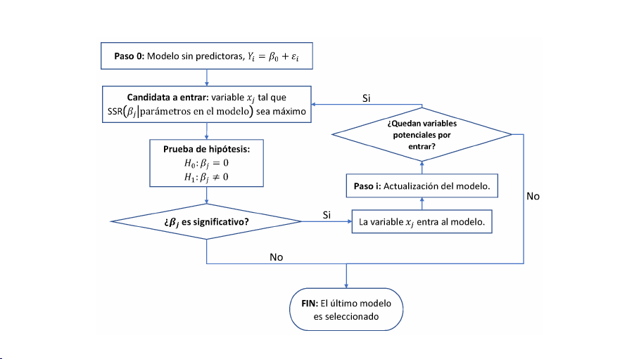

Proceso método forward

4 / 27

Método de eliminación hacia atrás (Backward)

Parte del modelo completo con todas las variables disponibles y elimina secuencialmente

de a una variable, buscando que el SSE no se reduzca signiﬁcativamente. La variable

que se elimina en cada paso, es aquella que no resulta signiﬁcativa en presencia de las

demás variables del modelo de regresión que se tiene en ese momento. También se

recurre a pruebas Fbasadas en sumas de cuadrados extras, y entre varias variables

candidatas a salir del modelo, se retira la de menor signiﬁcancia.El algoritmo se detiene

cuando todas las variables que aún permanecen en el modelo son signiﬁcativas en

presencia de las demás.

5 / 27

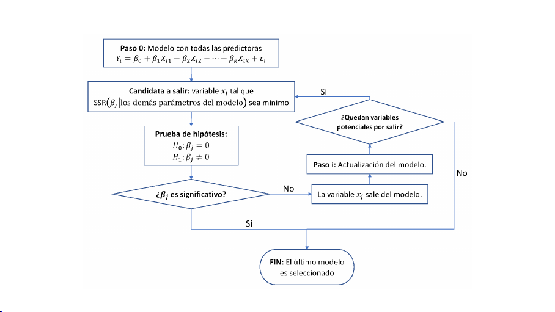

Proceso método backward

6 / 27

Método de selección paso a paso (Stepwise)

Comienza agregando variables, una a la vez, la nueva variable es ingresada según el

método forward, pero una vez ingresada una nueva variable, se evalúa que las demás que

ya estaban en el modelo sigan siendo signiﬁcativas, es decir, aplica el principio del

método backward. Así, en un paso dado puede ingresar una variable y salir otra que en

un paso previo ya había sido ingresada, es más, puede suceder que una misma variable

entre, salga y vuelva a ser ingresada en pasos subsiguientes del algoritmo. El algoritmo se

detiene cuando ya no hay más variables para ingresar que contribuyan signiﬁcativamente

a reducir el SSE, en tanto que todas las que se tienen en el modelo son signiﬁcativas.

7 / 27

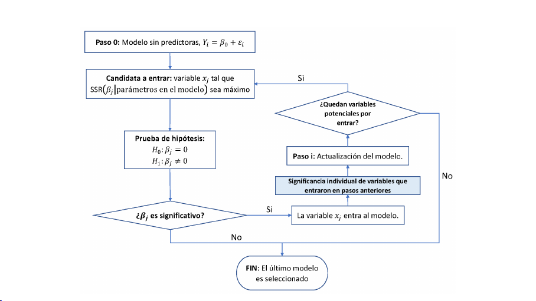

Proceso método stepwise

8 / 27

Algunas Recomendaciones

▶Como se anotó antes, el modelo ﬁnal no solamente debe ser el resultado de estos

métodos de selección automáticos, también es necesario usar el juicio y el

conocimiento previo que se tenga sobre el problema en el cual se está inmerso.

▶

Cuando una o más variables predictoras de tipo cualitativas son consideradas en un

modelo de regresión mediante un conjunto de variables indicadoras, en estos

procesos de selección de variables se recomienda mantener a éstas juntas, como un

solo grupo, aún si un subconjunto de ellas resulta mejor de acuerdo al criterio de

selección empleado.

9 / 27

▶

Esta recomendación también aplica en el caso de modelos en los cuales se incluyen

términos polinomiales de una variable, es decir, términos lineales, cuadráticos, etc.

Si un término polinómico de orden bde una variable dada va a ser dejado en el

modelo, entonces todos los términos de orden inferior de esa misma variable

también se recomienda dejarlos en el modelo, así no sean signiﬁcativos según el

criterio de selección aplicado.

▶Similarmente, si se tienen incluidos términos de interacción entre variables

predictoras, los términos de interacción de menor orden y los términos lineales de

las variables involucradas en tales interacciones, también deben permanecer en el

modelo.

10 / 27

Regresión con Variables Indicadoras

Considere el caso de una variable predictora Wmedida en una escala nominal u ordinal

(una variable categórica o cualitativa) deﬁnida en ccategorías.

Por ejemplo, en un estudio sobre la calidad de vida, aparece la variable W: estrato

socioeconómico del grupo familiar, deﬁnida en las categorías 1, 2, 3, 4, 5 y 6.

Aquí los valores 1 a 6 no representan información numérica y deben ser considerados

como simples etiquetas.

11 / 27

Suponga que se desea realizar una regresión lineal entre una variable cuantitativa Yvs.

la variable categórica W.

Dado la naturaleza cualitativa de ésta última no podemos simplemente formular el

modelo de regresión como:

Y=β0+β1W+ε, ε iid

∼N(0, σ2).

¿Cuál es la estrategia a seguir?

12 / 27

Uso de Variables Indicadoras para representar a W

Para cada categoría de Wse deﬁne una variable indicadora, es decir, una variable que

toma el valor de 1 ó 0 según si la categoría considerada es o no observada,

respectivamente, en una unidad experimental u de observación:

sean las variables Ij,j=1,...,c, tales que:

Ij=(1 si en la unidad experimental es observada la categoría j

0 si en la unidad experimental no es observada la categoría j.

Es decir, Ijes la variable indicadora de la categoría jde la variable cualitativa W.

13 / 27

Para una misma unidad experimental o de observación sólo una de las variables

indicadoras puede tomar el valor de 1, es decir, para la i-ésima observación se cumple

que: Pc

j=1Iij =1, de aquí que no es necesario considerar las cindicadoras

conjuntamente, ya que el valor de cualquiera de ellas en la unidad de observación i,

digamos de Iic , puede hallarse como Iic =1−Pc−1

j=1Iij .

Inicialmente, se puede proponer el siguiente modelo de RLM para modelar la relación de

Yvs. Wa través del uso de las variables indicadoras antes deﬁnidas, así:

Y=β0+β1I1+β2I2+. . . +βcIc+ε, ε iid

∼N(0, σ2)

14 / 27

Considere de nuevo el caso donde Wes el estrato socioeconómico y sea Yel gasto

medio mensual total de la familia. Suponga que se obtuvo una muestra aleatoria de dos

familias por cada estrato, para un total de n=12 observaciones (familias), entonces se

tiene un sistema de ecuaciones como el que se muestra a continuación:

Y1

Y2

Y3

Y4

Y5

Y6

Y7

Y8

Y9

Y10

Y11

Y12

=

1100000

1100000

1010000

1010000

1001000

1001000

1000100

1000100

1000010

1000010

1000001

1000001

β0

β1

β2

β3

β4

β5

β6

+

ε1

ε2

ε3

ε4

ε5

ε6

ε7

ε8

ε9

ε10

ε11

ε12

⇒Y=Xβ+ε,

15 / 27

Note que, en el sistema de ecuaciones anterior se tiene una dependencia lineal perfecta

entre la primera columna de la matriz Xy el resto de las columnas, ya que la primera se

puede escribir como la suma de las 6 restantes, lo cual hace a la matriz Xsingular y por

tanto que X⊤X−1

no exista y en consecuencia no se podría estimar el vector de

parámetros.

Para solucionar este inconveniente, se tienen tres posibles alternativas:

1. Eliminar el intercepto β0de la ecuación del modelo:

Y=β1I1+β2I2+· · · +βcIc+ε, ε iid

∼N(0, σ2)

En este caso, los βjrepresentan la media de Yen la categoría j, es decir,

E[Y|Ij=1] = βj.

16 / 27

2.

Eliminar una de las variables indicadoras, por ejemplo, aquella asociada a la última

categoría. En este caso, el coeﬁciente βj,j=c, representa el efecto o diferencia

promedio de la respuesta en la categoría jcon relación a la categoría c(nivel de

referencia). Entonces, tendríamos como modelo,

Y=β0+β1I1+β2I2+· · · +βc−1Ic−1+ε, ε iid

∼N(0, σ2)

3. Introducir la restricción Pc

j=1βj=0. Aquí, cada coeﬁciente βj,j=1,2,...,c

representa el efecto de la categoría jcon respecto a la media general de la

respuesta (intercepto):

Y=β0+β1I1+β2I2+· · · +βcIc+ε, ε iid

∼N(0, σ2)s.a.

c

X

j=1

βj=0

De estas tres alternativas usaremos la segunda.

17 / 27

Ahora suponga que se desea modelar la relación de una variable respuesta cuantitativa

Yvs. X, siendo Xcuantitativa, en presencia de una variable categórica W. Es decir, se

quiere determinar si la relación lineal entre YyXdepende de la variable categórica W.

Asumiendo que Wes observada en ccategorías, podemos considerar las dos siguientes

situaciones:

1. El efecto promedio de Xsobre la respuesta Yes el mismo en todas las categorías

de Wpero la media general de Yno es igual en todas las categorías. (cambios solo

de intercepto)

2.

El efecto promedio de Xsobre la respuesta Ycambia según la categoría en que W

sea observada. (cambios tanto de intercepto como de pendiente)

18 / 27

Caso 1. Modelo Básico

En el primer caso, el modelo a considerar es dado por

Y=β0+β1X+β2I1+β3I2+· · · +βcIc−1+ε, ε iid

∼N(0, σ2)

donde el efecto promedio de Xsobre la respuesta es el mismo sin importar la categoría

en que sea observada W, sin embargo, la media de Yno es la misma en todas las

categorías, es decir, las crectas resultantes son paralelas, así:

▶Si I1=1, Y= (β0+β2) + β1X+ε.

▶Si I2=1, Y= (β0+β3) + β1X+ε.

.

.

.

▶Si Ic−1=1, Y= (β0+βc) + β1X+ε.

▶Si I1=I2=· · · =Ic−1=0 (ó Ic=1), Y=β0+β1X+ε.

19 / 27

Caso 2. Modelo General con Interacciones

En el caso 2 es necesario considerar además de las c−1 variables indicadoras para

representar las categorías de la variable W(y así evitar el problema de la dependencia en

las columnas de la matriz de diseño), los términos de interacción (multiplicación) entre

la variable cuantitativa Xy las indicadoras que representan a Wen el modelo de

regresión, es decir, se postula el modelo

Y=β0+β1X+β2I1+β3I2+· · · +βcIc−1

+β1,1XI1+β1,2XI2+· · · +β1,c−1XIc−1+ε, ε iid

∼N(0, σ2)

donde XI

j

=X

∗

I

j

, es el término de interacción entre Xy la j-ésima variable indicadora,

j=1,...,c−1.

Observe que la ecuación anterior deﬁne crectas de regresión de Yvs. X, una por cada

categoría de la variable cualitativa W.

20 / 27

▶Si I1=1, entonces el resto de indicadoras son iguales a cero y se obtiene,

Y= (β0+β2)+(β1+β1,1)X+ε

▶Si I2=1, entonces el resto de indicadoras son iguales a cero y se obtiene,

Y= (β0+β3)+(β1+β1,2)X+ε

.

.

.

▶Si Ic−1=1, entonces el resto de indicadoras son iguales a cero y se obtiene,

Y= (β0+βc)+(β1+β1,c−1)X+ε

▶Finalmente, si I1=I2=· · · =Ic−1=0 implica que Ic=1, y se obtiene,

Y=β0+β1X1+ε

21 / 27

Ejemplo Ilustrativo

Un gran almacén realizó un experimento para investigar los efectos de los gastos por

publicidad sobre las ventas semanales de sus secciones de ropa para caballeros (A), para

niños (B) y para damas (C).

Acá las variables son:

▶Ventas semanales (respuesta Ycuantitativa, en miles de dólares).

▶Gastos de publicidad (predictora Xcuantitativa, en cientos de dólares).

▶Sección de ropa (predictora Wcualitativa) con tres niveles: Apara caballeros, B

para niños y Cpara damas.

22 / 27

Para representar la sección de ropa W, se deben deﬁnir dos variables indicadoras, así:

▶I1=(1,si la sección de ropa es A(caballeros)

0,en otro caso.

▶I2=(1,si la sección de ropa es B(niños)

0,en otro caso.

Note que el nivel de referencia es la sección de ropa C(damas).

Con el ﬁn de considerar las dos opciones de modelo se deben deﬁnir las interacciones

entre la predictora cuantitativa y las variables indicadoras que representan la predictora

cualitativa, así:

▶XI1=X∗I1.

▶XI2=X∗I2.

Veamos las dos alternativas de modelamiento para este ejemplo.

23 / 27

Caso 1. Modelo Básico Sin Interacciones

El modelo básico se plantea como:

Yi=β0+β1Xi+β2Ii1+β3Ii2+εi, εi

iid

∼N(0, σ2)∀i.

De donde se pueden extraer las rectas en cada nivel de W, así:

▶Si Ii1=1,Ii2=0→Yi= (β0+β2) + β1Xi+εi.

▶Si Ii1=0,Ii2=1→Yi= (β0+β3) + β1Xi+εi.

▶Si Ii1=0,Ii2=0→Yi=β0+β1Xi+εi.

24 / 27

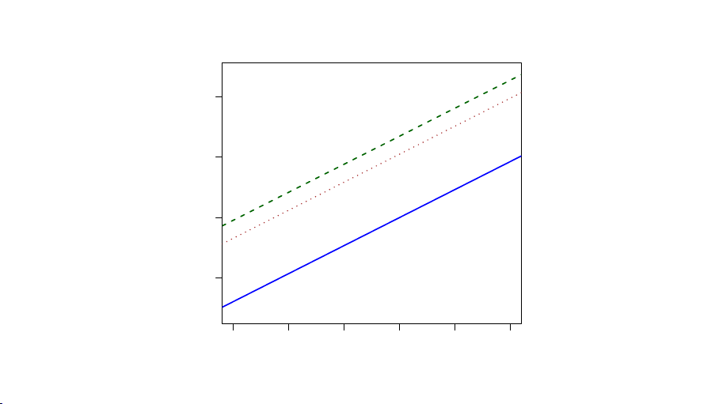

Gráﬁco Ilustrativo Modelo Básico

0 2 4 6 8 10

5

10

15

20

X

Y

Sección A

Sección B

Sección C (NR)

25 / 27

Caso 2. Modelo General con Interacciones

El modelo general se plantea como:

Yi=β0+β1Xi+β2Ii1+β3Ii2+β4XiIi1+β5XiIi2+εi, εi

iid

∼N(0, σ2)∀i.

De donde se pueden extraer las rectas en cada nivel de W, así:

▶Si Ii1=1,Ii2=0→Yi= (β0+β2)+(β1+β4)Xi+εi.

▶Si Ii1=0,Ii2=1→Yi= (β0+β3)+(β1+β5)Xi+εi.

▶Si Ii1=0,Ii2=0→Yi=β0+β1Xi+εi.

26 / 27

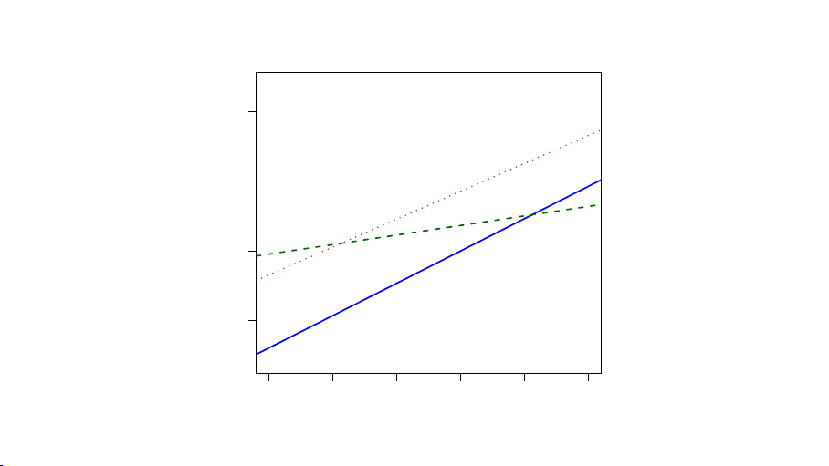

Gráﬁco Ilustrativo Modelo General

0 2 4 6 8 10

5

10

15

20

X

Y

Sección A

Sección B

Sección C (NR)

27 / 27